# Assignment_Week5

Hangsoo Jeong

10/7/2020

## load libraries

```r
library(tidyverse)
library(tidycensus)
library(jtools)
library(interactions)
```

## Load data

Same as in Assignment 4, I chose to mutate the income to be the comparison for the other variables, such as Work hours per week (continuous), Travel time to work (continuous), Sex (categorical), and Housing tenure Type (categorical). As some categories within the housing tenure variable have uncertain value(e.g., N/A (GQ/vacant)), I choose three subcategories(Rented, Owned with the loan, and Owned free and clear) in predicting income. My main interest is on the effect of the work hours per week and the travel time to work on the income. So, I will transform and apply the interaction term to the two variables for this assignment.

```r
tract_data <- read_csv("people.csv") %>%
  mutate(TEN_label = case_when(
    TEN_label=="Rented" ~ "Rented",
    TEN_label=="Owned with mortgage or loan (include home equity loans)" ~ "Owned with loan",
    TEN_label=="Owned free and clear" ~ "Owned free and clear"))
```

## Initial regression model

```r
model1 <- lm(PINCP ~ WKHP + JWMNP + SEX_label + TEN_label,
            data = tract_data)
summary(model1)
```

```
##
## Call:
## lm(formula = PINCP ~ WKHP + JWMNP + SEX_label + TEN_label, data = tract_data)
##
## Residuals:
##     Min      1Q  Median      3Q     Max
## -211379  -37599  -13921   13664 1231346
##
## Coefficients:
##                           Estimate Std. Error t value Pr(>|t|)
## (Intercept)              -15473.74    1856.93  -8.333  < 2e-16 ***
## WKHP                       2184.48      38.21  57.163  < 2e-16 ***
## JWMNP                       288.25      19.44  14.826  < 2e-16 ***
## SEX_labelMale             18215.40     932.26  19.539  < 2e-16 ***
## TEN_labelOwned with loan  -4891.69    1316.59  -3.715 0.000203 ***
## TEN_labelRented          -35744.98    1446.90 -24.705  < 2e-16 ***
## ---
## Signif. codes:  0 '***' 0.001 '**' 0.01 '*' 0.05 '.' 0.1 ' ' 1
##
## Residual standard error: 81410 on 32104 degrees of freedom
##   (1331 observations deleted due to missingness)
## Multiple R-squared:  0.1565, Adjusted R-squared:  0.1564
## F-statistic:  1192 on 5 and 32104 DF,  p-value: < 2.2e-16
```

## Log transformation

Try a log transformation on the travel time to work.

```r
model2 <- lm(PINCP ~ WKHP + log(JWMNP) + SEX_label + TEN_label,
            data = tract_data)
summary(model2)
```

```
##
## Call:
## lm(formula = PINCP ~ WKHP + log(JWMNP) + SEX_label + TEN_label,
##     data = tract_data)
##
## Residuals:
##     Min      1Q  Median      3Q     Max
## -212660  -37773  -13896   13778 1228960
##
## Coefficients:
##                           Estimate Std. Error t value Pr(>|t|)
## (Intercept)              -33487.79    2405.25 -13.923  < 2e-16 ***
## WKHP                       2174.11      38.28  56.802  < 2e-16 ***
## log(JWMNP)                 8699.61     571.29  15.228  < 2e-16 ***
## SEX_labelMale             18292.20     931.83  19.630  < 2e-16 ***
## TEN_labelOwned with loan  -4943.28    1316.40  -3.755 0.000174 ***
## TEN_labelRented          -36007.56    1446.32 -24.896  < 2e-16 ***
## ---
## Signif. codes:  0 '***' 0.001 '**' 0.01 '*' 0.05 '.' 0.1 ' ' 1
##
## Residual standard error: 81390 on 32104 degrees of freedom
##   (1331 observations deleted due to missingness)
## Multiple R-squared:  0.1569, Adjusted R-squared:  0.1567
## F-statistic:  1195 on 5 and 32104 DF,  p-value: < 2.2e-16
```

My R-squared value has improved very slightly, from 0.1564 to 0.1567. My interpretation of the results is that for every doubling of the travel time to work, the tract’s income increases by 8699.61. This result is statistically significant, but I’m not sure that it has limited practical significance because the change in income is so small based on a doubling of the travel time to work.

## Converting a continuous variable to a categorical variable

I’d like to see if converting the Work hours per week to a categorical variable has an effect in predicting income. For this, I simply load and use the workload level variable I have already created in the first assignment.

```r
model3 <- lm(PINCP ~ workload + log(JWMNP) + SEX_label + TEN_label,
            data = tract_data)
summary(model3)
```

```
##
## Call:
## lm(formula = PINCP ~ workload + log(JWMNP) + SEX_label + TEN_label,
##     data = tract_data)
##
## Residuals:
##     Min      1Q  Median      3Q     Max
## -139734  -38222  -14317   14596 1238069
##
## Coefficients:
##                          Estimate Std. Error t value Pr(>|t|)
## (Intercept)               83366.3     2376.3  35.082  < 2e-16 ***
## workloadLight            -81310.9     1656.5 -49.085  < 2e-16 ***
## workloadMedium           -44983.0     1044.2 -43.078  < 2e-16 ***
## log(JWMNP)                 9439.7      574.2  16.440  < 2e-16 ***
## SEX_labelMale             19453.9      932.7  20.858  < 2e-16 ***
## TEN_labelOwned with loan  -4469.7     1321.0  -3.383 0.000717 ***
## TEN_labelRented          -34168.6     1451.6 -23.539  < 2e-16 ***
## ---
## Signif. codes:  0 '***' 0.001 '**' 0.01 '*' 0.05 '.' 0.1 ' ' 1
##
## Residual standard error: 81690 on 32103 degrees of freedom
##   (1331 observations deleted due to missingness)
## Multiple R-squared:  0.1508, Adjusted R-squared:  0.1506
## F-statistic: 950.2 on 6 and 32103 DF,  p-value: < 2.2e-16
```

While the result is still statistically significant, my R-squared value has slightly decreased, from 0.1567 to 0.1506. It is not a better fitting model.

## Adding an interaction term

I was curious to see how an interaction between the log of the travel time to work and workload would impact the model fit.

```r
model4 <- lm(PINCP ~ workload + log(JWMNP) + SEX_label + TEN_label + workload:log(JWMNP),
            data = tract_data)
summary(model4)
```

```
##
## Call:
## lm(formula = PINCP ~ workload + log(JWMNP) + SEX_label + TEN_label +
##     workload:log(JWMNP), data = tract_data)
##
## Residuals:
##     Min      1Q  Median      3Q     Max
## -148152  -38137  -14339   14616 1237577
##
## Coefficients:
##                           Estimate Std. Error t value Pr(>|t|)
## (Intercept)                67673.8     3710.7  18.238  < 2e-16 ***
## workloadLight             -48961.1     6031.6  -8.117 4.93e-16 ***
## workloadMedium            -25192.1     4282.4  -5.883 4.08e-09 ***
## log(JWMNP)                 14287.4     1048.4  13.628  < 2e-16 ***
## SEX_labelMale              19472.7      932.6  20.879  < 2e-16 ***
## TEN_labelOwned with loan   -4621.3     1320.6  -3.499 0.000467 ***
## TEN_labelRented           -34035.4     1451.0 -23.457  < 2e-16 ***
## workloadLight:log(JWMNP)  -10713.2     1964.6  -5.453 4.99e-08 ***
## workloadMedium:log(JWMNP)  -6130.2     1289.0  -4.756 1.98e-06 ***
## ---
## Signif. codes:  0 '***' 0.001 '**' 0.01 '*' 0.05 '.' 0.1 ' ' 1
##
## Residual standard error: 81640 on 32101 degrees of freedom
##   (1331 observations deleted due to missingness)
## Multiple R-squared:  0.1518, Adjusted R-squared:  0.1516
## F-statistic:   718 on 8 and 32101 DF,  p-value: < 2.2e-16
```

The R-squared value is slightly increased to 0.1516. And all my results are statistically significant. The interaction terms between the log of the travel time to work and the workload categories tells us that for every doubling of travel time to work, the income decreases for both light and medium work level with heavy work level as my base case.

## Visualizing the results

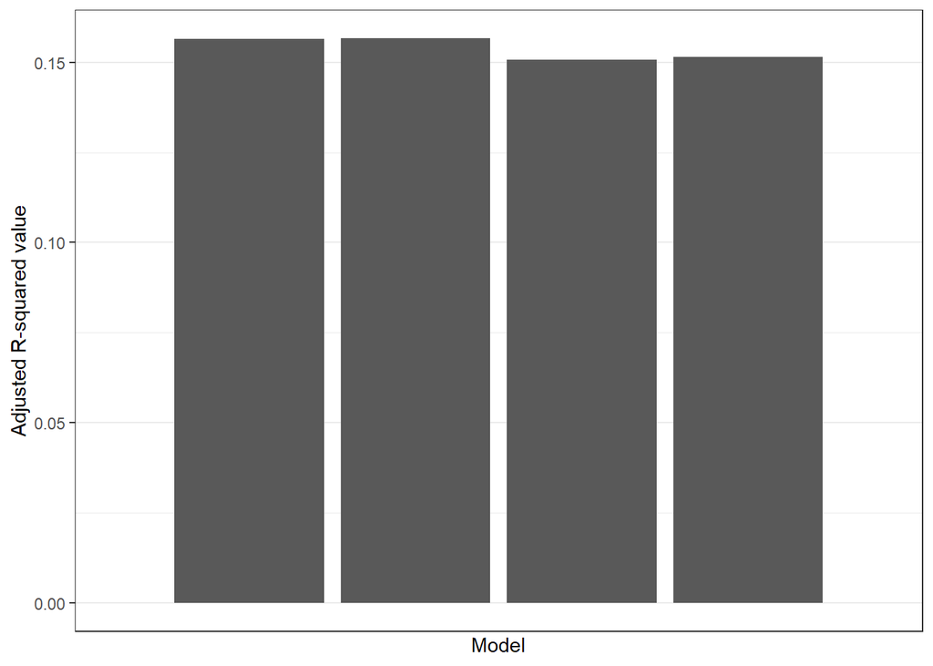

```r
ModelFit <- tibble(model = c(1, 2, 3, 4),
                   R_square = c(summary(model1)$adj.r.squared,
                                summary(model2)$adj.r.squared,
                                summary(model3)$adj.r.squared,
                                summary(model4)$adj.r.squared))
ggplot(ModelFit, aes(x = model, y = R_square)) +
  geom_col() +
  scale_x_discrete(name = "Model",
                   breaks = breaks <- seq(1, 4, by = 1),
                   labels = paste("Model", breaks)) +
  scale_y_continuous(name = "Adjusted R-squared value") +
  theme_bw()
```

Model 2 is my best fit.

## Visualize regression results

Model 2 is my best fit. So, I visualize its results related to the work hours per week and the log transformation on the travel time to work, which are the variables that I have been interested in predicting income.

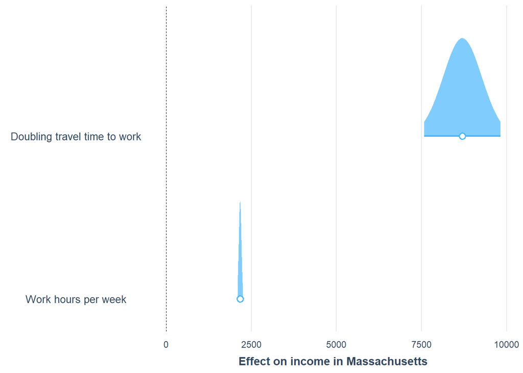

```r
coeff_desc <- c("Work hours per week" = "WKHP",
                "Doubling travel time to work" = "log(JWMNP)")
plot_coefs(model2,
           coefs = coeff_desc,
           plot.distributions = TRUE,
           rescale.distributions = TRUE) +
  scale_x_continuous(name = "Effect on income in Massachusetts")
```